# The acoustic correlates of quantity in Inari Saami - ScienceDirect

- [View **PDF**](https://www.sciencedirect.com/science/article/pii/S0095447018300470/pdfft?md5=10a879e13ac99e06c4ae270fda7b5813&pid=1-s2.0-S0095447018300470-main.pdf)

## Cited By (4)

## Figures (8)

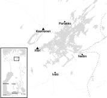

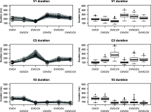

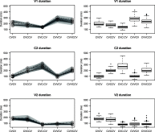

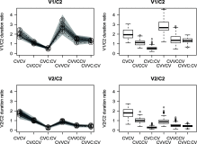

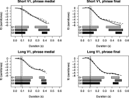

## Tables (10)

1. Table 1
2. Table 2
3. Table 3
4. Table 4
5. Table 5
6. Table 6

## Extras (1)

1. Supplementary data 1

## [Journal of Phonetics](https://www.sciencedirect.com/journal/journal-of-phonetics)

[Volume 72](https://www.sciencedirect.com/journal/journal-of-phonetics/vol/72/suppl/C), January 2019, Pages 35-51

# Research Article The acoustic correlates of quantity in Inari Saami

[HelenTürk](https://www.sciencedirect.com/science/article/pii/S0095447018300470#!)[PärtelLippus](https://www.sciencedirect.com/science/article/pii/S0095447018300470#!)[KarlPajusalu](https://www.sciencedirect.com/science/article/pii/S0095447018300470#!)[PireTeras](https://www.sciencedirect.com/science/article/pii/S0095447018300470#!)

https://doi.org/10.1016/j.wocn.2018.11.001[Get rights and content](https://s100.copyright.com/AppDispatchServlet?publisherName=ELS&contentID=S0095447018300470&orderBeanReset=true)

## Highlights

**•**

There is a robust three-way quantity distinction of the consonant in Inari Saami.

**•**

The duration of the surrounding vowels is in an inverse relation with consonant length.

**•**

F0 variability associated with quantity is negligible.

**•**

Consonant quantity affects the intensity of the unstressed vowel.

## Abstract

This paper studies the phonetic realisation of the ternary length opposition of consonants in Inari Saami disyllabic feet focussing on the distinction between half-long and long geminates. Inari Saami is compared with other Saami and Finnic languages. Segmental durations, fundamental frequency and intensity are analysed. The results show a three-way distinction in consonant duration most robustly after a short stressed syllable vowel. In the case of a long stressed syllable vowel there is no difference between half-long and long geminates. In all of the analysed word structures, segments are inversely related to each other, as with an increase in consonant duration the durations of the surrounding vowels decrease. The fall in the fundamental frequency contour is less steep in words with a long geminate than in those with a short consonant or a half-long geminate. The intensity of the unstressed vowel decreases with the increasing quantity of the intervocalic consonant. The results indicate that the three-way quantity distinction in Inari Saami is primarily manifested by durational properties in a disyllabic foot, while fundamental frequency and intensity have a less important role.

## Keywords

Word prosody

Three-way quantity contrast

Geminates

Inari Saami

## 1. Introduction

The aim of this study is to investigate how the ternary contrast of consonantal quantity in Inari Saami is realised in different foot structures. Durational properties, fundamental frequency and intensity patterns are investigated. Parts of the results of this research have been presented in Türk et al., 2014, Türk et al., 2015, Türk et al., 2016. This paper continues the previous studies with the focus on the distinction between half-long and long geminates, which occur in the intervocalic position on the boundary of the stressed and unstressed syllable. Throughout the paper V1 denotes the vowel in the first syllable, C2 the intervocalic consonant, and V2 the vowel in the second syllable of a disyllabic word.

The three-way length contrast in general has been claimed to exist only in a handful of languages. Ternary vowel length distinctions have been reported in Estonian (Lehiste, 2003), Livonian (Lehiste et al., 2008), Dinka (Remijsen & Gilley, 2008), Yavapai (Thomas and Shaterian, 1990, Thomas, 1992), Mixe (Hoogshagen, 1959) and Yupik (Leer, 1985). The presence of a three-way vocalic length has also been discussed for Seri, Mayo and Hopi (languages of the Americas), Standard High German, Low and Central Franconian, Scottish Gaelic, Seneca, and Sarcee, but no clear evidence has been found to confirm its existence in these languages (cf. McRobbie-Utasi, 2007, Prehn, 2012 for more details).

Three distinctive lengths for consonants are found only in some Finnic (Markus, Lippus, Pajusalu, & Teras, 2012) and Saami languages (Baal, Odden, & Rice, 2012 for North Saami; Bye, Sagulin, & Toivonen, 2009 for Inari Saami; Fangel-Gustavson, Ridouane, & Morén-Duolljá, 2014 for Lule Saami). In the Saami language group, the contrast is made between short (referred to as Q1) consonants, half-long (Q2) geminates, and long (Q3) geminates<sup>1</sup>. Historically, the phonetic distinction between half-long and long geminates has been proposed to occur already in Proto-Finnic (Lehtinen, 2007), but is not found in other modern Finnic languages. Moreover, in the Finnic language Estonian a more complex system of ternary length contrast exists, where the three degrees of length are contrastive for both vowels and consonants.

In Estonian the domain of quantity is a left-headed disyllabic foot, and the opposition of short (Q1; /sɑte/ ‘fall-out’), long (Q2; /sɑːte/ ‘broadcast’; /sɑtte/ ‘fall’; /sɑɑtte/ ‘get, pl. 2nd pers.’) and overlong quantity (Q3; /sɑɑːte/ ‘haystack, pl. part.’; /sɑtːte/ ‘fall, sg. gen.’; /sɑɑtːte/ ‘broadcast, sg. gen.’) occurs in the stressed feet (cf. Eek and Meister, 1997, Lehiste, 2003, Lippus et al., 2013). The segments in a disyllabic foot are interrelated: V2 is half-long after a short syllable and shortened to a great extent after an overlong syllable. The duration ratios of the stressed and unstressed syllables in a disyllabic foot are roughly 2/3 for Q1, 3/2 for Q2 and 2/1 for Q3 (Lehiste, 1960). The distinction between half-long and long geminates in Estonian is present after both short and long vowels (the distinction after long vowels is limited to voiceless obstruents).

### 1.1. Inari Saami language situation

Inari Saami (*anarâškielâ*) belongs to the group of Eastern Saami languages and is spoken around Lake Inari in northern Finland by approximately 250 native speakers (Fernandez-Vest, 2012). Therefore, it is considered a seriously endangered indigenous language.

There are five main villages of Inari Saami: Ivalo, Inari, Kaamanen, Partakko and Nellim, which are shown in Fig. 1. The settlement in the Inari Saami speaking area, especially in the latter three villages, is sparse. The fact that the speakers live relatively far away from each other gives rise to a considerable variability within the language. There are four main dialects of Inari Saami – northern, eastern, western and southern (Äimä, 1914, Itkonen et al., 1989). In the older literature the differences between dialects have not been considered very remarkable, and the borders between the dialect areas are not exactly clear; however, the most noticeable differences are between (north-)western and (south-)eastern dialects. The literary language of Inari Saami dates back to the 1850s and exhibits different dialectal variants, which have been admitted in the norm (Olthuis, 2000).

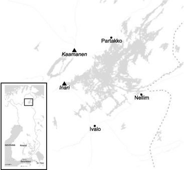

1. [Download : Download high-res image (140KB)](https://ars.els-cdn.com/content/image/1-s2.0-S0095447018300470-gr1_lrg.jpg)
2. [Download : Download full-size image](https://ars.els-cdn.com/content/image/1-s2.0-S0095447018300470-gr1.jpg)

Fig. 1. A map showing the five Inari villages around Lake Inari; the villages marked with triangles represent the areas the speakers of our study come from (base maps from Stamen Maps available under CC BY 3.0).

Since 1980 the number of Inari Saami speakers has been decreasing, because the speakers are mostly elderly and there are no new young speakers. Many families have taken over Finnish as their main language and speak it to their children in order to avoid negative attitudes at Finnish-speaking schools (Olthuis, 2000). Thus, the youngest generation is bilingual or even predominantly Finnish speaking, using Inari Saami as their second language. In 1997 a revitalisation process of Inari Saami was started and two language nests (i.e., kindergartens or preschools where only a minority language is used) were established: one in Ivalo and one in Inari (Aikio-Puoskari, 2009, Pasanen, 2015). For adults (mostly teachers, social workers, journalists) whose knowledge in Inari Saami was insufficient, a one-year intensive course was carried out in 2009–2010 (Bhatia & Ritchie, 2008). University of Oulu has degree programmes of Saami Culture and Saami Language and a Bachelor’s programme is offered in Inari Saami, where Inari Saami is also used as a [language of instruction](https://www.sciencedirect.com/topics/social-sciences/language-of-instruction).

### 1.2. Quantity in Inari Saami

The vowel phoneme inventory of Inari Saami consists of the vowels /i, y, u, e, ɤ, o, æ, ɑ/ which are written in the orthography as i, y, u, e, â, o, ä/á, a, respectively. Note that /æ/ is represented by both ä and á, where ä is only used in the first syllable with /i/ or /e/ in the second syllable. The consonant phoneme system has /p, t, k, b, d, ɡ, t͡s, t͡ʃ, d͡z, d͡ʒ, f, s, ʃ, h, v, ð, m, n, ŋ, r, l, j/, which are written in the orthography as p, t, k, b, d, g, c, č, z, ž, f, s, š, h, v, đ, m, n, ŋ, r, l, j, respectively (Morottaja, Kuuva, & Olthuis, 2012). All consonants occur as geminates in the intervocalic position (Bye, 2007). The three-way quantity distinction in Inari Saami is manifested by the opposition of short consonants (Q1), half-long (Q2) and long (Q3) geminates or consonant clusters on the boundary of the stressed and unstressed syllable. Vowels in Inari Saami are either short or long; both short and long monophthongs as well as diphthongs occur as V1, while V2 is always phonologically short (Äimä, 1914, Bye, 2007, Itkonen, 1946, Sammallahti, 1998).

Previous acoustic–phonetic studies of the consonantal quantity distinction in Inari Saami have focused on the durational aspects of quantity (Bye et al., 2009, Markus et al., 2012). Bye et al. (2009) measured the durations of V1, C2 and V2 in disyllabic words with both short and long V1 and short V2. The intervocalic consonants were sonorants /l, m, n/. According to their results the average duration of a short consonant is 78 ms, that of a half-long geminate is 144 ms and long geminate 191 ms (it is not specified separately for words with short and long V1). The ratio of Q2 geminates to Q1 consonants is 1.85 and the ratio of Q3 geminates to Q2 geminates is 1.33. In the feet with a short V1, Bye et al. (2009) report a clear ternary distinction in consonant duration. While for some speakers there was an inverse relation between the durations of V1 and C2 (the longer the consonant, the shorter the vowel), others showed more variation in V1 duration. Markus et al. (2012) studied the three-way opposition of consonant quantity in Inari Saami disyllabic feet with a short V1 and also report a three-way distinction in consonant duration. Similar to the findings of Bye et al. (2009) for one speaker, Markus et al. (2012) did not find a significant correlation between V1 and C2 duration. In both studies, the speakers most distinctively shortened the V2 duration after half-long and long geminates.

In feet with a long V1 the previous results are not completely clear. Two of the five speakers of Bye et al. (2009), who were from the western dialect area, realised the ternary distinction in consonant duration after a long V1, while three speakers from the eastern dialect area did not. V1 duration itself in most cases was negatively correlated with the duration of the following consonant. The speakers did not have the distinction in V2 after short consonants and half-long geminates, and some speakers actually had longer V2 after long than after half-long geminates.

### 1.3. Three-way quantity in other Saami languages

The quantity distinction in Saami languages includes the ternary opposition of consonants only and vowels have a binary opposition. This ternary consonantal quantity distinction has been observed and studied in Inari (Bye et al., 2009), Skolt (McRobbie-Utasi, 2007), North (Baal et al., 2012) and Lule Saami (Fangel-Gustavson et al., 2014). It has been claimed to exist in Pite Saami by Lehtiranta (1992), but not by Wilbur (2014). The same is true about Ume Saami, where consonants have been said to be short, long and overlong, occurring with phonological restrictions (Schlachter, 1958, von Gertten, 2015). However, no phonetic studies have been carried out and thus the realisation of quantity in Pite and Ume Saami remains unclear. In Kildin Saami, consonants can be short or long (Wilbur, 2007); South Saami also exhibits a two-way opposition – only geminates occur after short vowels, and consonant length after long vowels is distinctively short or long (Hasselbrink, 1981), but again, this has not been studied acoustically.

McRobbie-Utasi (2007) shows that in **Skolt Saami** the average duration of the intervocalic consonant increases with quantity: a short consonant is 87 ms, a half-long 163 ms and a long geminate 249 ms. The ratio of half-long geminates to short consonants is 1.87 and the ratio of long geminates to half-long geminates is 1.53. V1 is either a short or long monophthong or a diphthong, and V2 is a short or long monophthong only (Feist, 2010). There is an inverse relation between the duration of the intervocalic consonant and the preceding vowel – with the increasing duration of the consonant the vowel is shortened. The duration of the following vowel is not influenced by consonant length. McRobbie-Utasi (2007) states that in Skolt Saami the domain of quantity is the first vowel and the consonant(s) of the disyllabic unit.

In **North Saami** word-medial consonants have three degrees of length: short consonants (Q1), half-long or long geminates, and consonant clusters (Q2 or Q3, respectively). According to Bals, Odden, and Rice (2007) the average durations of short consonants, half-long and long geminates are 120, 276 and 338 ms. The ratio between Q1 and Q2 is considerably greater (2.30) than it is between Q2 and Q3 geminates (1.22). Vowel inventories differ across dialects of North Saami, but both monophthongs and diphthongs occur in two degrees of length, i.e. short and long. Long diphthongs are about twice as long as the short ones. There are phonological restrictions for combining the vowel length and consonant length: a long geminate must be preceded by a short vowel, while a half-long geminate must be preceded by a long vowel (cf. Magga, 1984). In addition to duration, fundamental frequency also distinguishes long and short diphthongs, the former having a falling F0 and the latter a more level F0 (McRobbie-Utasi, 2007).

In sum, all four previously discussed Saami languages – Inari, Skolt, North and Lule Saami – show a three-way distinction in consonant duration, whereas vowels are either short or long, except in Lule Saami where only short vowels can be found. In North and Skolt Saami the duration of V1 is affected by the increasing duration of the following consonant, while in Lule and Inari Saami both vowels are somewhat influenced by the C2 length, but the influence is greater in the case of the vowels following the intervocalic consonant. The duration ratios of consonant segments appear to show differences forming two groups. Table 1 shows the duration ratios of a half-long geminate to a short consonant (CC/C), a long geminate to a half-long geminate (C:C/CC), and a long geminate to a short consonant (C:C/C) in the four Saami languages. The ratio of a half-long geminate to a short consonant is less than two in Inari and Skolt Saami, while the ratio is greater than two in Lule and North Saami. The ratio of a long geminate to a half-long geminate is considerably smaller ranging from 1.2 to 1.5. The ratio of a long geminate to a short consonant is 3.6 in Lule Saami, but in the case of North, Skolt and Inari Saami it is smaller and ranges from 2.5 to 2.9.

Table 1. Ratios of a half-long geminate to a short consonant (CC/C), a long geminate to a short consonant (C:C/C) and a long geminate to a half-long geminate (C:C/CC) in four Saami languages.

| Empty Cell | CC/C | C:C/C | C:C/CC |
| --- | --- | --- | --- |
| Inari Saami (Bye et al., 2009) | 1.85 | 2.45 | 1.33 |
| Skolt Saami (McRobbie-Utasi, 2007) | 1.87 | 2.86 | 1.53 |
| North Saami (Bals et al., 2007) | 2.30 | 2.82 | 1.22 |
| Lule Saami (Fangel-Gustavson et al., 2014) | 2.39 | 3.59 | 1.50 |

### 1.4. Research questions

The aim of the present research is to study how the ternary contrast of consonantal quantity in Inari Saami is realised in the case of foot structures that have short and long vowels or diphthongs as the first syllable nucleus. Our research questions are based on earlier studies on quantity in Inari Saami.

The three-way quantity contrast in Inari Saami is manifested on the boundary of the stressed and unstressed syllables in a disyllabic foot and the main correlate of quantity is duration. We study the temporal features of all sounds in Inari Saami disyllabic feet with short consonants, half-long and long geminates and consonant clusters. The data consists of all consonants of the Inari Saami consonant inventory. Consonant clusters have not been studied in previous research on Inari Saami quantity, but we would expect them to behave similarly to geminates. In our analysis we include disyllabic words with both short and long V1. Since previous studies have indicated that there is certain variation in the durational manifestation of the three-way quantity contrast in different word structures, we aim to expand on this issue, and clarify whether and how the ternary distinction is realised in feet with different structures. We give more detailed insight into the durational aspects of quantity by using test material from the main Inari speaking area around Inari village. Bye et al. (2009) argue that the existence of the three-way distinction in consonant duration after a long vowel correlates with the dialectal background of the speakers: speakers representing the western dialect area realise the distinction, while speakers of the eastern dialect area do not. Our speakers come from the (north-)western dialect area, complementing the two western dialect area speakers of Bye et al. (2009), and therefore, they should realise the three-way distinction in consonant duration after a long vowel and exhibit a longer V2 after a long geminate than after a half-long geminate.

In addition, we focus on the distinction between half-long and long geminates. According to Markus et al. (2012), who studied the disyllabic words with a short V1, in Estonian, Ingrian and Inari Saami the ratio of half-long geminates and short consonants is greater (2.19, 2.42, 1.81, respectively) than the ratio between long and half-long geminates (1.40, 1.30, 1.52, respectively). In Livonian it is the other way round, as long and half-long geminates have a bigger ratio (1.78) than half-long geminates and short consonants (1.49). Based on earlier results, the ratio of half-long geminates and short consonants in this study is expected to be greater than the ratio of long and half-long geminates.

In Saami languages the secondary features of quantity have not been studied in great detail. Furthermore, to our knowledge there are no previous studies concerning the effects of quantity on fundamental frequency contours and intensity values in Inari Saami. In Lule Saami it has been shown that quantity does not affect F0 (Fangel-Gustavson et al., 2014). In other Finno-Ugric languages, such as Estonian and Finnish, F0 has been shown to vary in terms of quantity. In Estonian the difference in fundamental frequency contours emerges in the opposition of Q1 and Q2 vs. Q3 (Lehiste, 1960, Lippus et al., 2013). For Finnish different results have been found. According to Suomi, Toivanen, and Ylitalo (2003) there is no influence of quantity on F0, but later findings of Vainio, Järvikivi, Aalto, and Suni (2010) show that syllables with a short vowel are associated with a static high tonal target and long syllables with a dynamic falling target. Motivated by the variability between languages on the one hand and between different studies on the other, one of the aims of this paper is to investigate the tonal patterns induced by quantity in Inari Saami disyllabic foot structures.

Quantity has been found to influence the intensity of the vowels surrounding the consonant in Lule Saami (Fangel-Gustavson et al., 2014), and in Skolt Saami it has been shown that quantity influences the intensity of the following vowel (McRobbie-Utasi, 2007). It is assumed that in Inari Saami the intensity of the vowels is also affected by quantity.

## 2. Material and method

### 2.1. Material

The speakers of this study were four males aged 62, 68, 76 and 77 years (average age 70.8). They were all native speakers of Inari Saami; two of them were born in Inari, one in Syysjärvi and one in Ylivieska. At the time of recording, the speakers lived in the northern and western areas of Inari Saami (cf. the areas in and around the villages marked with triangles in Fig. 1). All subjects spoke Finnish and three reported a good knowledge of North Saami, as well. This group of elderly speakers was chosen for the study, since they represent the older generation of Inari Saami speakers before the revitalisation process of the language, and use Inari Saami as their first language. They formed a homogenous group of speakers who lived geographically close to each other, and were thus expected not to vary dialectally in their use of language. The fact that some speakers of Inari Saami are not sufficiently accustomed to reading the language further narrowed the choice of speakers for the task.

The recordings took place in quiet settings using an Edirol R-09 digital recorder at a sampling rate of 48 kHz with 16 bits per sample. The recorder with internal microphone was placed at approximately 50 cm from the speaker. The subjects were asked to read the carrier sentences printed on a sheet of paper and to repeat the sentences in the cases of mispronunciation. The corpus is available at the Center of Estonian Language Resources (cf. Lippus, Teras, Pajusalu, & Türk, 2018).

The carrier sentences contained target words with six different foot structures: CVCV, CVCCV, CVC:CV(C), CVVCV(C), CVVCCV(C), CVVC:CVC. Examples for all of the word structures and the number of tokens for each structure are presented in Table 2. The first three word structures in Table 2 have a short vowel or a diphthong in the first syllable (V1) followed by a short (referred to as Q1) consonant, half-long (Q2) or long (Q3) geminate or consonant cluster (C2). The stressed syllable of the last three word types contains a long vowel or a diphthong followed by a short consonant, a half-long or a long geminate or a consonant cluster. The vowel in the second syllable (V2) was always phonologically short and the syllable was either open or closed by a short voiced consonant. The test sentences were written in the orthography as used in the dictionary of Inari Saami<sup>2</sup> (Sammallahti & Morottaja, 1993), where half-long geminates are marked with a dot under the single letter; long geminates are written with two letters, and an apostrophe before a consonant cluster refers to a short consonant cluster (e.g., Q1 *sare* /sɑre/ ‘blueberry, acc/gen.sg’, Q2 *saṛe* /sɑrre/ ‘blueberry, nom.sg’, Q3 *pállu* /pælːlu/ ‘ball, nom.sg’; Q2 *ša'lde* /ʃɑlte/ ‘bridge, acc/gen.sg’.’, Q3 *šalde* /ʃɑlːte/ ‘bridge, nom.sg’).

Table 2. The six different foot structures and examples with monophthongs and diphthongs in the first syllable (S1), as well as the number of tokens for each structure.

| Foot structure | S1 monophthong | S1 diphthong | No. of tokens |
| --- | --- | --- | --- |
| CVCV | *sare* /sɑre/ ‘blueberry, acc/[gen.sg](http://gen.sg/)’ | *kye’le* /kyele/ ‘fish, acc/[gen.sg](http://gen.sg/)’ | 42 |
| CVCCV | *saṛe* /sɑrre/ ‘blueberry, [nom.sg](http://nom.sg/)’ | – | 114 |
| CVC:CV(C) | *pállu* /pælːlu/ ‘ball, [nom.sg](http://nom.sg/)’ | *uáb'bi* /uæbːbi/ ‘sister, [nom.sg](http://nom.sg/)’ | 496 |
| CVVCV(C) | *määli* /mææli/ ‘soup, acc/[gen.sg](http://gen.sg/)’ | *muorâ* /muorɤ/ ‘tree, acc/[gen.sg](http://gen.sg/)’ | 195 |
| CVVCCV(C) | *määḷi* /mæælli/ ‘soup, [nom.sg](http://nom.sg/)’ | *muoṛâ* /muorrɤ/ ‘tree, [nom.sg](http://nom.sg/)’ | 529 |
| CVVC:CVC | *määllid* /mæælːlid/ ‘soup, [part.sg](http://part.sg/)’ | *muorrâd* /muorːrɤd/ ‘tree, [part.sg](http://part.sg/)’ | 87 |

The target words occurred in phrase-medial (see example (a) below) and phrase-final or sentence-final (example (b)) position of the carrier sentences. These positions denoted the places of contrastive stress in the sentences as there was contrastive stress in phrase-final position, but not in phrase-medial position. Examples of the sentences are as follows:

**(a)**

*Ohtâ* *maṇe* *lii taa, mut ohtâ* *lodde* *lii tobbeen.* ‘One **egg** is here, but one **bird** is there.’

**(b)**

*Mist láá kuttâ* *sare**, mut sist láá kuttâ* *juuŋâ.* ‘We have six **blueberries**, but they have six **lingonberries**.’

Table 3. The distribution of test words.

| Empty Cell C2 | Duration Short V1 | Duration Long V1 | F0 Short V1 | F0 Long V1 | Intensity Short V1 | Intensity Long V1 |
| --- | --- | --- | --- | --- | --- | --- |
| Short cons. | 40 | 195 | 34 | 144 | 37 | 100 |
| Q2 geminate | 82 | 340 | 61 | 212 | 58 | 169 |
| Q2 cluster | 32 | 190 | 29 | 129 | – | 39 |
| Q3 geminate | 258 | 88 | 175 | 74 | 90 | 67 |
| Q3 cluster | 238 | – | 185 | – | 37 | – |
| Total | 650 | 813 | 484 | 559 | 222 | 375 |

Table 4. The distribution of C2 consonants and consonant clusters by C2 quantity.

| C2 cons | Q1 | Q2 | Q3 | C2 cluster | Q2 | Q3 |
| --- | --- | --- | --- | --- | --- | --- |
| p | – | 17 | 16 | bs | 16 | 17 |
| t | – | 27 | 16 | sk | 12 | 16 |
| k | – | 24 | 49 | vd | 17 | 15 |
| b | 7 | 9 | 16 | vr | 16 | 16 |
| d | 29 | 22 | 32 | nd | 16 | 16 |
| s | – | 28 | 32 | rɡ | 16 | 16 |
| h | 49 | 16 | – | rn | 16 | 16 |
| v | 8 | 36 | – | rj | 12 | 16 |
| m | 21 | 37 | 25 | lk | 4 | 16 |
| n | 32 | 81 | 64 | ld | 12 | 16 |
| ŋ | 12 | 4 | 16 | lɡ | 12 | 16 |
| r | 32 | 36 | 16 | lh | 12 | – |
| l | 45 | 68 | 47 | lj | 16 | 16 |
|  |  |  |  | jb | 16 | 16 |
|  |  |  |  | jd | 30 | 32 |

Table 5. The distribution of V1 and V2 vowels by C2 quantity.

| V1 vowel | Q1 | Q2 | Q3 | V1 diphthong | Q1 | Q2 | Q3 | V2 vowel | Q1 | Q2 | Q3 |
| --- | --- | --- | --- | --- | --- | --- | --- | --- | --- | --- | --- |
| i | 8 | 66 | 66 | iæ | 0 | 40 | 15 | i | 62 | 196 | 214 |
| u | 24 | 36 | 32 | ie | 13 | 41 | 39 | u | 62 | 79 | 89 |
| e | 0 | 60 | 79 | ye | 8 | 20 | 24 | e | 40 | 79 | 96 |
| ɤ | 12 | 12 | 8 | uæ | 24 | 40 | 40 | ɤ | 61 | 139 | 122 |
| o | 8 | 37 | 31 | uo | 12 | 28 | 26 | o | 0 | 12 | 16 |
| æ | 110 | 173 | 145 |  |  |  |  | æ | 10 | 120 | 47 |
| ɑ | 16 | 91 | 79 |  |  |  |  | ɑ | 0 | 19 | 0 |

### 2.2. Measurements and statistical analysis

The durations of all segments of the test words were labelled and measured in Praat (Boersma and Weenink (2017)). For the F0 analysis the standard autocorrelation method was used with the pitch floor and ceiling optimised for each speaker. The contours were further smoothed and interpolated. The values for fundamental frequency were obtained from the beginning of the first vowel (V1) to the end of the second vowel (V2) from 20 equally spaced points. This way, the fundamental frequency contour was obtained for each foot. The values measured in Hertz were converted into semitones (st) in reference to 50 Hz. The fundamental frequency turning point was found by calculating the time (in milliseconds) from the beginning of V1 to the next point after F0 maximum where the F0 was falling. The linear regression slope of the fundamental frequency in relation to the turning point in V1 and time normalised in relation to the whole word was found. For the analysis of intensity, the mean values of V1, C2 and V2 were extracted in decibels.

Statistical analysis was carried out using the LME4 package in R (Bates, Maechler, Bolker, & Walker, 2014). Using mixed-effect modeling the log-scaled segmental durations were tested. Separate models were run with the duration of each segment (C1 duration, V1 duration, C2 duration, V2 duration) as a dependent variable and C2 length (3 levels: short, half-long, long) and phrasal position (2 levels: phrase-medial, phrase-final) as fixed factors. The speakers and the test words were added in the models as random factors. The models were built in an incremental fashion by adding fixed factors for testing their main effects and interactions. A similar mixed-effect modeling approach was used for testing the characteristics of F0 (the average values of F0 in V1 and V2, F0 maximum in V1, F0 minimum in V2, the turning point, the difference between V1 maximum and V2 minimum, slope) and the mean values of V1, C2, and V2 intensity and the difference between V1 and V2 intensity. For post-hoc testing Tukey HSD was used.

## 3. Results

### 3.1. Segment durations

This section investigates the temporal properties of Inari Saami geminate consonants and consonant clusters as well as the relations of segments in the foot. The manifestation of the ternary distinction of consonant quantity is studied in word structures containing phonologically short and long vowels before intervocalic consonants while succeeding vowels are always short (cf. Table 2). The results for the segmental durations are followed by the analysis of the duration ratios of segments.

Fig. 2 illustrates the average segment durations in different foot structures with a phonologically short (left panel) and long (right panel) first syllable vowel. Table 6, Table 7 provide the numeric data for the average durations and standard deviations of each segment, respectively for the words with a short and long vowel before a consonant. Fig. 3, Fig. 4 show the average segmental durations by individual speakers (left panels) and across all speakers (right panels); Fig. 3 presents durations for words with geminates, and Fig. 4 for consonant clusters. In all of the following figures and tables, C1 marks the word-initial consonant, V1 is a short or long vowel or diphthong in the first syllable, C2 a short intervocalic consonant (Q1), a half-long (Q2) and long (Q3) geminate or consonant cluster, and V2 stands for a short vowel in the second syllable. The mean values are calculated as [arithmetic means](https://www.sciencedirect.com/topics/social-sciences/arithmetic-mean) of durations for each segment. In Fig. 2 the mean durations of segments are calculated over both phrasal positions. In Table 6, Table 7, the means are first calculated separately for phrase-medial and phrase-final positions, followed by the mean values of each segment over both phrasal positions (rows for “average”). Columns V1/C1 and V2/C2 show the mean values of the duration ratios of V1/C1 and V2/C2. For each token V1 duration was divided by C2 duration and V2 duration was divided by C2 duration and the mean was calculated over these ratios.

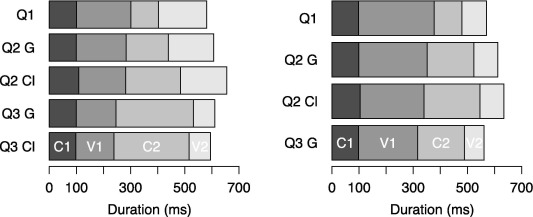

1. [Download : Download high-res image (148KB)](https://ars.els-cdn.com/content/image/1-s2.0-S0095447018300470-gr2_lrg.jpg)
2. [Download : Download full-size image](https://ars.els-cdn.com/content/image/1-s2.0-S0095447018300470-gr2.jpg)

Fig. 2. Mean segment durations in words with a phonologically short V1 (left panel) and long V1 (right panel). The three quantities of C2 are marked with Q1, Q2 and Q3, and G stands for a geminate and Cl for a consonant cluster.

Table 6. Mean segment durations and standard deviations (in milliseconds) in phrase-medial (no contrastive stress) and phrase-final (contrastive stress) position and both positions analysed together for the words with short V1.

| Pos. | Structure | C1 | V1 | **C2** | V2 | Total | V1/C2 | V2/C2 |
| --- | --- | --- | --- | --- | --- | --- | --- | --- |
| Phrase-medial | Q1 short C | 103 | 183 | **93** | 167 | 525 | 2.1 | 1.9 |
|  | s.d. | 18 | 26 | **27** | 21 | 52 | 0.5 | 0.5 |
|  | Q2 geminate | 96 | 166 | **138** | 151 | 539 | 1.2 | 1.1 |
|  | s.d. | 23 | 24 | **25** | 22 | 54 | 0.3 | 0.2 |
|  | Q2 cluster | 110 | 161 | **185** | 148 | 577 | 0.9 | 0.8 |
|  | s.d. | 17 | 31 | **27** | 26 | 60 | 0.2 | 0.2 |
|  | Q3 geminate | 98 | 140 | **242** | 79 | 539 | 0.6 | 0.3 |
|  | s.d. | 26 | 26 | **66** | 24 | 89 | 0.2 | 0.1 |
|  | Q3 cluster | 95 | 132 | **239** | 74 | 526 | 0.6 | 0.3 |
|  | s.d. | 21 | 19 | **44** | 12 | 62 | 0.1 | 0.1 |
| Phrase-final | Q1 short C | 99 | 217 | **112** | 189 | 597 | 2.0 | 1.8 |
|  | s.d. | 16 | 44 | **23** | 40 | 77 | 0.5 | 0.5 |
|  | Q2 geminate | 102 | 195 | **167** | 177 | 626 | 1.2 | 1.1 |
|  | s.d. | 24 | 35 | **38** | 40 | 93 | 0.3 | 0.3 |
|  | Q2 cluster | 107 | 186 | **220** | 192 | 678 | 0.9 | 0.9 |
|  | s.d. | 17 | 29 | **36** | 39 | 91 | 0.2 | 0.1 |
|  | Q3 geminate | 101 | 149 | **323** | 102 | 653 | 0.5 | 0.3 |
|  | s.d. | 27 | 32 | **72** | 41 | 95 | 0.2 | 0.1 |
|  | Q3 cluster | 100 | 149 | **317** | 95 | 645 | 0.5 | 0.3 |
|  | s.d. | 23 | 23 | **53** | 32 | 84 | 0.1 | 0.1 |
| Average | Q1 short C | 101 | 200 | **102** | 178 | 561 | 2.0 | 1.8 |
|  | s.d. | 17 | 40 | **27** | 33 | 74 | 0.5 | 0.5 |
|  | Q2 geminate | 100 | 184 | **156** | 167 | 592 | 1.2 | 1.1 |
|  | s.d. | 24 | 34 | **36** | 37 | 90 | 0.3 | 0.2 |
|  | Q2 cluster | 109 | 173 | **203** | 170 | 628 | 0.9 | 0.8 |
|  | s.d. | 16 | 32 | **36** | 40 | 92 | 0.2 | 0.2 |
|  | Q3 geminate | 98 | 144 | **284** | 91 | 599 | 0.6 | 0.3 |
|  | s.d. | 27 | 29 | **80** | 36 | 108 | 0.2 | 0.1 |
|  | Q3 cluster | 97 | 141 | **280** | 85 | 589 | 0.5 | 0.3 |
|  | s.d. | 22 | 23 | **63** | 27 | 95 | 0.1 | 0.1 |

C2 values are highlighted in bold.

Table 7. Mean segment durations and standard deviations (in milliseconds) in phrase-medial (no contrastive stress) and phrase-final (contrastive stress) position and both positions analysed together for the words with long V1.

| Pos. | Structure | C1 | V1 | **C2** | V2 | Total | V1/C2 | V2/C2 |
| --- | --- | --- | --- | --- | --- | --- | --- | --- |
| Phrase-medial | Q1 short C | 96 | 238 | **89** | 74 | 491 | 2.8 | 0.9 |
|  | s.d. | 22 | 49 | **16** | 12 | 64 | 0.7 | 0.2 |
|  | Q2 geminate | 94 | 215 | **142** | 73 | 519 | 1.6 | 0.6 |
|  | s.d. | 23 | 38 | **40** | 13 | 71 | 0.5 | 0.2 |
|  | Q2 cluster | 104 | 204 | **173** | 67 | 538 | 1.2 | 0.4 |
|  | s.d. | 18 | 49 | **31** | 12 | 66 | 0.3 | 0.1 |
|  | Q3 geminate | 98 | 199 | **157** | 65 | 519 | 1.3 | 0.4 |
|  | s.d. | 20 | 26 | **32** | 10 | 44 | 0.3 | 0.1 |
| Phrase-final | Q1 short C | 98 | 298 | **109** | 98 | 592 | 2.9 | 0.9 |
|  | s.d. | 26 | 40 | **26** | 30 | 61 | 0.8 | 0.4 |
|  | Q2 geminate | 101 | 266 | **183** | 93 | 633 | 1.6 | 0.5 |
|  | s.d. | 28 | 44 | **51** | 30 | 90 | 0.4 | 0.2 |
|  | Q2 cluster | 104 | 246 | **217** | 95 | 650 | 1.2 | 0.4 |
|  | s.d. | 31 | 41 | **39** | 27 | 76 | 0.3 | 01 |
|  | Q3 geminate | 99 | 236 | **189** | 81 | 604 | 1.3 | 0.4 |
|  | s.d. | 17 | 28 | **39** | 19 | 52 | 0.3 | 0.1 |
| Average | Q1 short C | 99 | 279 | **103** | 91 | 561 | 2.8 | 0.9 |
|  | s.d. | 25 | 51 | **25** | 28 | 77 | 0.8 | 0.3 |
|  | Q2 geminate | 99 | 253 | **172** | 88 | 603 | 1.6 | 0.5 |
|  | s.d. | 27 | 48 | **52** | 28 | 99 | 0.5 | 0.2 |
|  | Q2 cluster | 104 | 236 | **206** | 88 | 623 | 1.2 | 0.4 |
|  | s.d. | 28 | 47 | **42** | 27 | 87 | 0.3 | 0.1 |
|  | Q3 geminate | 98 | 218 | **173** | 73 | 562 | 1.3 | 0.4 |
|  | s.d. | 18 | 33 | **39** | 17 | 64 | 0.3 | 0.1 |

C2 values are highlighted in bold.

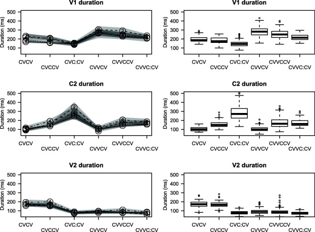

1. [Download : Download high-res image (494KB)](https://ars.els-cdn.com/content/image/1-s2.0-S0095447018300470-gr3_lrg.jpg)
2. [Download : Download full-size image](https://ars.els-cdn.com/content/image/1-s2.0-S0095447018300470-gr3.jpg)

Fig. 3. Segmental durations (V1, C2, V2) in six word structures by individual speakers (left panels) and across all speakers (right panels) for words with geminates. The numbers in circles denote mean values of segment durations for each speaker and the shaded areas show 25% and 75% quantiles (the darker the colour the more overlap between speakers).

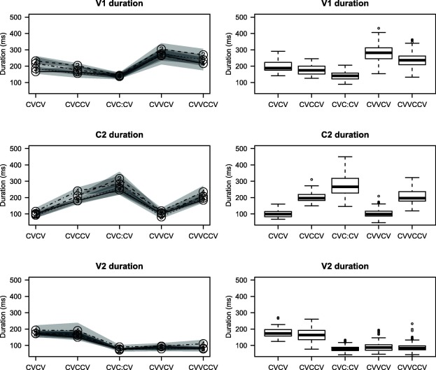

1. [Download : Download high-res image (484KB)](https://ars.els-cdn.com/content/image/1-s2.0-S0095447018300470-gr4_lrg.jpg)
2. [Download : Download full-size image](https://ars.els-cdn.com/content/image/1-s2.0-S0095447018300470-gr4.jpg)

Fig. 4. Segmental durations (V1, C2, V2) in five word structures by individual speakers (left panels) and across all speakers (right panels) for words with consonant clusters. The numbers in circles denote mean values of segment durations for each speaker and the shaded areas show 25% and 75% quantiles (the darker the colour the more overlap between speakers).

For describing the duration of each segment, mixed-effects models were run separately for subsets of the data. Word structures with a short and long V1 were considered independently, and within these groups, word structures with geminates and consonant clusters were tested separately. Thus, models were run for four groups of words: short V1 and geminates, short V1 and consonant clusters, long V1 and geminates, long V1 and consonant clusters.

Next, the durations of segments are discussed separately for word structures with a short V1 and long V1. The results for different speakers (as seen in Fig. 3, Fig. 4) show similar patterns and overlaps, which indicates that all four speakers form a homogenous group in terms of producing the quantity distinction. Therefore, the results of individual speakers are not discussed in further detail. In addition, words in phrase-medial and phrase-final position are pooled together. In phrase-final position, the durations of all segments (except C1) are longer, which also indicates the effect of final lengthening.

#### 3.1.1. Words with short V1

The effects of C2 length, phrasal position and their interaction on segmental durations (C1, V1, C2, V2) were tested with mixed-effects models separately for words with geminates and consonant clusters. No influence of C2 length nor phrasal position on the duration of the word-initial consonant was found.

There was a main effect of C2 length on V1 duration (words with geminates: [*F*(2, 104.14) = 36.30, *p* < 0.001]; words with consonant clusters: [*F*(2, 81.26) = 62.28, *p* < 0.001]). As seen in the left panel in Fig. 2 and upper two panels in Fig. 3, Fig. 4, V1 was the longest before a short consonant (200 ms), shorter before a half-long geminate (184 ms) or a consonant cluster (173 ms), and the shortest before a long geminate (144 ms) or a consonant cluster (141 ms). Post-hoc testing showed a difference in V1 duration between Q1 and Q2 vs. Q3 for geminates (*p* < 0.001) and a three-way distinction for consonant clusters (Q1 vs. Q2 *p* < 0.05, Q1 and Q2 vs. Q3 *p* < 0.001). V1 was significantly longer in phrase-final position compared to phrase-medial position (words with geminates: [*F*(1, 94.17) = 13.06, *p* < 0.001]; words with consonant clusters [*F*(1, 86.18) = 41.54, *p* < 0.001]).

After a short V1 the duration of C2 was significantly affected by C2 length (words with geminates: [*F*(2, 101.15) = 220.15, *p* < 0.001]; words with consonant clusters: [*F*(2, 73.02) = 302.30, *p* < 0.001]). The average duration of an intervocalic short consonant was 102 ms, a half-long geminate was 156 ms and a long geminate 284 ms; a half-long consonant cluster was 203 ms and a long consonant cluster 280 ms long. The post-hoc tests showed a significant difference between all pairs (*p* < 0.001). A half-long geminate was shorter than a half-long consonant cluster, whereas a long geminate and consonant cluster were of similar duration. There was also a significant main effect of phrasal position on C2, such that C2 has longer durations in phrase-final position than in phrase-medial position (geminates: [*F*(1, 90.73) = 56.42, *p* < 0.001]; consonant clusters: [*F*(1, 87.65) = 100.54, *p* < 0.001]).

V2 duration was significantly affected by C2 length (words with geminates: [*F*(2, 102.99) = 303.43, *p* < 0.001]; words with consonant clusters: [*F*(2, 78.60) = 345.58, *p* < 0.001]). As seen in Table 6, the average duration of V2 after a short consonant was 178 ms, after a half-long geminate 167 ms and after a half-long consonant cluster 170 ms, after a long geminate 91 ms and after a long consonant cluster 85 ms. Post-hoc testing showed a significant difference in the opposition of Q1 and Q2 vs. Q3 (*p* < 0.001 for all pairs). There was no significant difference in V2 duration after short consonants vs. half-long geminates/consonant clusters (*p* > 0.05). V2 in phrase-final position was significantly longer than in phrase-medial position (words with geminates: [*F*(1, 93.63) = 21.93, *p* < 0.001]; words with consonant clusters: [*F*(1, 80.34) = 48.65, *p* < 0.001]).

The effect of the type of the unstressed syllable (S2 type; levels: open, closed) on the duration of V2 was not significant for words with geminates, but for words with short consonants and consonant clusters V2 was significantly [*F*(1, 70.34) = 9.14, *p* < 0.01]) longer in the open syllable compared to the closed one (118 and 77 ms, respectively). There was no interaction between C2 length and S2 type, showing that the effect of S2 Type on V2 duration was the same regardless of the preceding C2 length.

#### 3.1.2. Words with long V1

The average segment durations in different foot structures with a long V1 are shown in the right panel of Fig. 2 and the numeric data is provided in Table 7 (cf. Fig. 3, Fig. 4 with average segmental durations for different speakers). It should be noted that words in which a long V1 was followed by a long consonant cluster were lacking in the data. In the models with consonant clusters, comparisons were made between a short consonant and a half-long consonant cluster only.

The results of the fixed-effects models for word structures with a long V1 showed no main effects of C2 length nor phrasal position on C1 duration. There was a significant main effect of C2 length (words with geminates: [*F*(2, 158.19) = 37.43, *p* < 0.001]; words with consonant clusters: [*F*(2, 93.37) = 78.70, *p* < 0.001]) on V1 duration. V1 was the longest before a short consonant (279 ms); it was shorter before a half-long geminate or consonant cluster (253 ms and 236 ms, respectively) and further shortened before a long geminate (218 ms). Post-hoc testing for words with geminates also showed a significant difference between all three quantities (*p* < 0.001). Phrasal position had a significant main effect on V1 duration with longer segmental durations phrase-finally than phrase-medially (words with geminates: [*F*(1, 163.65) = 167.63, *p* < 0.001]; words with consonant clusters: [*F*(1, 91.61) = 82.36, *p* < 0.001]).

C2 after a long V1 was significantly affected by C2 length (words with geminates: [*F*(2, 166.61) = 150.67, *p* < 0.001]; words with consonant clusters: [*F*(2, 95.37) = 712.62, *p* < 0.001]). The average duration of a short consonant was 103 ms, half-long and long geminates were longer in duration – 172 and 173 ms, respectively. A half-long consonant cluster was 206 ms. Post-hoc testing for words with geminates showed a significant difference in the opposition of Q1 vs. Q2 and Q3 (*p* < 0.001 for both pairs). The difference between Q2 and Q3 was not significant (*p* > 0.05).

C2 was significantly longer phrase-finally than phrase-medially (words with geminates: [*F*(1, 173.87) = 59.51, *p* < 0.001]; words with consonant clusters: [*F*(1, 91.61) = 52.11, *p* < 0.001]). As seen in Table 7, the durations of half-long and long geminates differ slightly when considering phrase-medial position and phrase-final position separately. Therefore, additional models were run for each of these positions individually. The results still confirmed no significant differences between half-long and long geminates.

There was a significant main effect of C2 length on V2 duration in words with geminates [*F*(2, 153.51) = 32.62, *p* < 0.001]. The duration of V2 was the shortest after a long geminate (73 ms), longer after a half-long geminate or consonant cluster (88 ms after both), and the longest after a short consonant (91 ms). According to the post-hoc testing there were significant differences in V2 duration after Q1 vs. Q3 and Q2 vs. Q3 (*p* < 0.001 for both pairs). The durations of V2 after a short consonant and a half-long geminate and consonant cluster did not differ significantly (*p* > 0.05). The main effect of phrasal position was significant for both, words with geminates [*F*(1, 155.93) = 27.17, *p* < 0.001] and consonant clusters [*F*(1, 102.32) = 19.57, *p* < 0.001] with longer durations phrase-finally.

There was a significant effect of the S2 type (open or closed) on V2 duration in the word structures with a long V1 (words with geminates: [*F*(1, 149.15) = 68.11, *p* < 0.001]; words with consonant clusters: [*F*(1, 104.49) = 68.98, *p* < 0.001]). Surprisingly, in an open second syllable, V2 was shorter in duration (78 ms) than in a closed syllable (100 ms). There was no interaction between C2 length and S2 type.

#### 3.1.3. Duration ratios

In order to further illustrate the relations between the segments within the disyllabic word the duration ratios were calculated. Fig. 5 shows the duration ratios of V1/C2 (upper panels) and V2/C2 (lower panels) in the analysed six word structures whereas geminates and consonant clusters are pooled together. Again, the results for different speakers (left panels in Fig. 5) were similar.

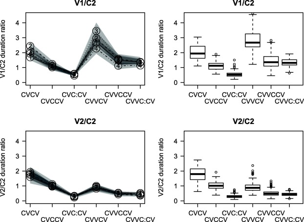

1. [Download : Download high-res image (422KB)](https://ars.els-cdn.com/content/image/1-s2.0-S0095447018300470-gr5_lrg.jpg)
2. [Download : Download full-size image](https://ars.els-cdn.com/content/image/1-s2.0-S0095447018300470-gr5.jpg)

Fig. 5. Duration ratios of V1/C2 (upper panels) and V2/C2 (lower panels) for six word structures by individual speakers (left panels) and across all speakers (right panels). The numbers in circles denote the mean values of segment durations for each speaker and the shaded areas show 25% and 75% quantiles (the darker the colour the more overlap between speakers).

In words with a short V1, the results of the mixed-effects models showed a main effect of C2 length on the ratios of both V1/C2 [*F*(2, 163.08) = 529.24, *p* < 0.001] and V2/C2 [*F*(2, 165.88) = 956.56, *p* < 0.001]. The duration ratios were in inverse relationship with consonant quantity. The ratio of V1/C2 was the greatest in words with a short consonant (with the value of 2.0), smaller with a half-long geminate/consonant cluster (1.1) and the smallest with a long geminate/consonant cluster (0.5). Post-hoc testing showed a significant difference between all the pairs (*p* < 0.001). The ratio of V2/C2 was also the greatest in words with a short consonant (1.8), smaller with a half-long geminate/consonant cluster (1.0) and the smallest with a long geminate/consonant cluster (0.3). A Tukey post-hoc test showed a significant difference for all pairs (*p* < 0.001). The main effect of phrasal position was significant for both duration ratios, V1/C2 [*F*(1, 163.16) = 11.07, *p* < 0.001] and V2/C2 [*F*(1, 164.34) = 4.54, *p* < 0.05] with smaller ratios in phrase-final than in phrase-medial position. However, there was no interaction between C2 length and phrasal position, which shows that irrespective of the effects of stress the duration ratios are preserved.

In words with a long V1, there was a main effect of C2 length on both the ratio of V1/C2 [*F*(2, 208.84) = 282.79, *p* < 0.001] and that of V2/C2 [*F*(2, 221.16) = 120.24, *p* < 0.001]. The duration ratio of V1/C2 was the greatest in words with a short intervocalic consonant (2.8) and equally smaller in words with half-long and long geminates/consonant clusters (1.4 and 1.3, respectively). The results of post-hoc testing showed a significant difference between Q1 vs. Q2 and Q3 (*p* < 0.001). The same pattern emerged in the case of the duration ratio of V2/C2, where the ratio was the greatest with a short C2 (0.9) and smaller with a half long and long geminate/consonant cluster (0.5 and 0.4, respectively). A Tukey post-hoc test confirmed a significant difference in the opposition of Q1 vs. Q2 and Q3 (*p* < 0.001). In words with a long V1 there was no significant main effect of phrasal position on the duration ratio of V2/C2 (*p* > 0.05).

### 3.2. Fundamental frequency

The fundamental frequency patterns in Inari Saami have not been described in previous studies, but our data showed that the general pitch contour has an H* target on the stressed syllable, which, regardless of the contrastive condition, is followed by an L tone. Table 8 summarises the results for the analysis of fundamental frequency showing the temporal location of the F0 turning point (TP, time from V1 beginning in milliseconds), the average values of F0 in V1 and V2, F0 maximum in V1, F0 minimum in V2, the difference between V1 maximum and V2 minimum (F0 range), and F0 slope.

Table 8. Average values of F0 turning point time in milliseconds (TP, time from V1 beginning), maximum F0 of V1 (V1 F0 max), minimum F0 of V2 (V2 F0 min), the difference between V1 F0 max and V2 F0 min (max-min) and F0 slope in semitones.

| Pos. | Foot structure | C2 | TP | V1 F0 | V2 F0 | V1 F0 max | V2 F0 min | max-min | F0 slope |
| --- | --- | --- | --- | --- | --- | --- | --- | --- | --- |
| Phrase-medial | CVCV | short | 91 | 16.7 | 12.9 | 17.6 | 11.8 | 5.8 | −5.8 |
|  | CVCCV | gem. | 97 | 17.0 | 13.2 | 17.8 | 12.3 | 5.5 | −5.8 |
|  |  | clust. | 97 | 16.8 | 12.7 | 17.9 | 11.7 | 6.2 | −5.2 |
|  | CVC:CV(C) | gem. | 94 | 16.7 | 13.3 | 17.6 | 12.7 | 4.9 | −4.6 |
|  |  | clust. | 89 | 17.3 | 13.1 | 18.1 | 12.5 | 5.6 | −5.3 |
|  | CVVCV(C) | short | 78 | 15.4 | 12.4 | 16.9 | 11.9 | 5 | −4.9 |
|  | CVVCCV(C) | gem. | 97 | 16.3 | 13.2 | 17.7 | 12.6 | 5.1 | −4.2 |
|  |  | clust. | 94 | 16.4 | 12.7 | 17.6 | 12.2 | 5.4 | −5.4 |
|  | CVVC:CV(C) | gem. | 92 | 16.5 | 12.5 | 17.6 | 12.1 | 5.5 | −5.4 |
| Phrase-final | CVCV | short | 103 | 16.6 | 12.1 | 17.8 | 11.2 | 6.6 | −7.9 |
|  | CVCCV | gem. | 123 | 17.5 | 13.3 | 18.9 | 12.3 | 6.6 | −7.8 |
|  |  | clust. | 121 | 17.9 | 12.9 | 18.9 | 11.9 | 7 | −7.6 |
|  | CVC:CV(C) | gem. | 110 | 12.6 | 14.0 | 19.1 | 13.4 | 5.7 | −5.6 |
|  |  | clust. | 108 | 18.1 | 12.3 | 18.9 | 11.7 | 7.2 | −6.1 |
|  | CVVCV(C) | short | 105 | 15.8 | 12.2 | 18.4 | 11.5 | 6.9 | −6.0 |
|  | CVVCCV(C) | gem. | 116 | 16.7 | 12.5 | 18.9 | 12.0 | 6.9 | −7.0 |
|  |  | clust. | 108 | 17.0 | 12.5 | 19.1 | 11.9 | 7.2 | −6.1 |
|  | CVVC:CV(C) | gem. | 102 | 16.6 | 12.3 | 18.4 | 11.8 | 6.6 | −6.4 |

The F0 turning point was defined as the time from V1 beginning to the point after F0 maximum where the F0 was 5% lower than the full range. The F0 slope was calculated by fitting a linear regression line on time-normalised F0 measurements. The F0 measurements were normalised in reference to the F0 maximum and the time was normalised in reference to the duration from the turning point to the end of a word. With mixed-effect modeling the main effects of C2 length and phrasal position as well as their interaction effect on the F0 characteristics were tested. Separate models were run for word structures with a short V1 followed by geminates, a long V1 followed by geminates, a short V1 followed by consonant clusters, and a long V1 followed by consonant clusters. Fig. 6 shows the fundamental frequency contours in words with short consonants, half-long and long geminates and consonant clusters together.

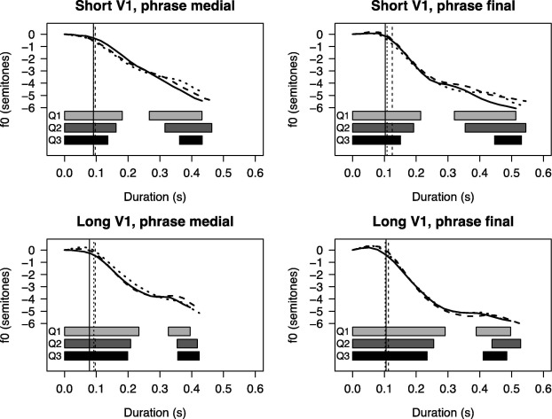

1. [Download : Download high-res image (449KB)](https://ars.els-cdn.com/content/image/1-s2.0-S0095447018300470-gr6_lrg.jpg)
2. [Download : Download full-size image](https://ars.els-cdn.com/content/image/1-s2.0-S0095447018300470-gr6.jpg)

Fig. 6. F0 contours (in semitones, normalised to the beginning of V1) in two positions of a test sentence (phrase-medial and phrase-final) and in word structures with a short and long V1. Solid contours mark the foot structures with a short intervocalic consonant, dashed ones stand for a half-long and dotted ones for a long geminate/consonant cluster. Horizontal bars denote the durations of V1 and V2 in words with intervocalic Q1, Q2 and Q3 consonants. Vertical line shows the location of the F0 turning point.

#### 3.2.1. Words with short V1

The main effect of C2 length on the F0 range, i.e., on the difference between the F0 maximum of V1 and F0 minimum of V2 (cf. the max–min column in Table 8 and the upper two panels in Fig. 6) was significant for the words with consonant clusters only [*F*(1, 65.63) = 7.34, *p* < 0.01]. The range was significantly greater with a long consonant cluster (7.2 st) than with a short consonant (6.6 st) in phrase-final position (*p* < 0.05). There was a significant main effect of phrasal position on the F0 range in the case of both: words with geminates [*F*(1, 70.07) = 10.04, *p* < 0.01] and consonant clusters [*F*(1, 69.49) = 21.00, *p* < 0.001] had greater values in phrase-final than in phrase-medial position.

The F0 turning point (cf. TP column in Table 8) was affected by phrasal position in words with consonant clusters [*F*(1, 76.95) = 5.84, *p* < 0.05], where it occurred later phrase-finally than phrase-medially. Phrasal position did not have a significant effect on the F0 turning point in words with geminates.

A significant main effect of C2 length [*F*(2, 74.34) = 5.86, *p* < 0.01] on the F0 slope was found for the words with geminates. The slope was greater in words with a short consonant and a half-long geminate (both −5.8 st in phrase-medial and −7.9 and −7.8 st, respectively, in phrase-final position) than with a long geminate (−4.6 st in phrase-medial and −5.6 st in phrase-final position). Post-hoc testing showed significant differences between Q1 vs. Q3 (*p* < 0.01) and Q2 vs. Q3 (*p* < 0.05). There was no significant effect of quantity on the F0 slope in words with consonant clusters, but the main effect of phrasal position on the slope in these words was significant [*F*(1, 52.10) = 10.54, *p* < 0.01]. The values were greater in phrase-final compared to phrase-medial position.

There was a main effect of C2 length [*F*(2, 60.56) = 7.26, *p* < 0.01] and phrasal position [*F*(1, 62.83) = 4.53, *p* < 0.05] on F0 at the beginning of V2 in words with geminates. However, post-hoc testing showed a significant difference only between Q1 (14.2 st) and Q3 (13.8 st) in phrase-medial position (*p* < 0.05). The main effect of C2 length on F0 at the beginning of V2 was also significant for words with consonant clusters [*F*(1, 242.04) = 21.02, *p* < 0.001]. After a short consonant F0 was 13.7 st, after a half-long consonant cluster it was 14.1 st and after a long consonant cluster 13.3 st. There was a significant difference between Q1 and Q2 vs. Q3 (*p* < 0.001).

The average F0 values in V1 and V2 were not affected by the C2 length and phrasal position, except in words with consonant clusters, where there was a significant main effect of phrasal position [*F*(1, 45.69) = 10.22, *p* < 0.01] on the F0 in V2 with smaller values phrase-finally.

#### 3.2.2. Words with long V1

In words with a long V1, there was a significant main effect of phrasal position on many F0 characteristics, which means that the values were generally more enhanced when the words were in phrase-final compared to phrase-medial position (cf. the lower two panels in Fig. 6). The F0 range was greater phrase-finally than phrase-medially (words with geminates: [*F*(1, 132.34) = 33.13, *p* < 0.001]; words with consonant clusters: [*F*(1, 68.11) = 13.96, *p* < 0.001]) and the F0 turning point also occurred later phrase-finally (words with geminates: [*F*(1, 127.39) = 11.33, *p* < 0.01], words with consonant clusters: [*F*(1, 71.08) = 7.75, *p* < 0.01]). Similarly, the F0 slope was greater in phrase-final than in phrase-medial position (words with geminates: [*F*(1, 88.25) = 16.84, *p* < 0.001], words with consonant clusters: [*F*(1, 49.66) = 12.50, *p* < 0.001]). The values of F0 at the beginning of V1 were greater phrase-finally than phrase-medially (words with geminates: [*F*(1, 58.59) = 14.41, *p* < 0.001]; words with consonant clusters: [*F*(1, 12.23) = 9.72, *p* < 0.01]), while the average F0 of V2 was smaller in phrase-final compared to phrase-medial position (words with geminates: [*F*(1, 88.36) = 10.61, *p* < 0.001], words with consonant clusters: [*F*(1, 58.24) = 5.03, *p* < 0.05]). This result shows the effects of the sentences’ contrastive stress conditions: phrase-medial position carried no contrastive stress, while phrase-final position had contrastive stress.

There was a significant main effect of C2 length on the average values of F0 in V1 (words with geminates: [*F*(2, 114.87) = 3.57, *p* < 0.05]; words with consonant clusters: [*F*(1, 75.93) = 11.89, *p* < 0.001]). The average value of F0 in V1 before a short consonant was 15.6 st, before a half-long geminate 16.6 st, and before a long geminate 16.5 st. Post-hoc testing showed a significant difference between Q1 vs. Q2 and Q3 (*p* < 0.05). The average value of F0 in V1 before a half-long consonant cluster was 16.8 ms.

The difference between Q2 and Q3 geminates emerged at the end of V1 as there was a significant main effect of C2 length [*F*(1, 81.98) = 8.35, *p* < 0.001] on F0 values. Before a short consonant, the F0 at the end of V1 was 13.1 st, before a half-long geminate 13.8 st, and before a long geminate 14.3 st. Post-hoc testing showed a significant difference between Q1 and Q3 (*p* < 0.001) and Q2 and Q3 (*p* < 0.01).

### 3.3. Intensity

Table 9 presents the results of the mean values of the intensity of V1, C2 and V2 in different word structures in phrase-medial and phrase-final positions. Fig. 7 shows the difference between the intensity values of V1 and V2 in two phrasal positions. Left panels in Fig. 7 show that there is some variation between speakers in phrase-medial position and more overlap in phrase-final position.

Table 9. The average intensity (in dB) of the first (V1) and the second (V2) syllable vowel and the intervocalic consonant (C2). The last column shows the intensity difference between V1 and V2 (V1–V2).

| Pos. | Foot structure | V1 | C2 | V2 | V1–V2 |
| --- | --- | --- | --- | --- | --- |
| Phrase-medial | CVCV | 65.5 | 60.2 | 61.6 | 3.9 |
|  | CVCCV | 66.1 | 58.4 | 59.9 | 6.2 |
|  | CVC:CV(C) | 66.3 | 58.1 | 58.5 | 7.8 |
|  | CVVCV(C) | 65.0 | 57.9 | 59.3 | 5.7 |
|  | CVVCCV(C) | 66.1 | 58.0 | 59.8 | 6.3 |
|  | CVVC:CV(C) | 65.7 | 57.9 | 59.4 | 6.3 |
| Phrase-final | CVCV | 65.9 | 58.5 | 59.0 | 6.9 |
|  | CVCCV | 66.9 | 57.9 | 57.8 | 9.1 |
|  | CVC:CV(C) | 66.0 | 56.0 | 53.5 | 12.5 |
|  | CVVCV(C) | 65.9 | 57.6 | 57.8 | 8.1 |
|  | CVVCCV(C) | 66.5 | 56.5 | 57.6 | 8.9 |
|  | CVVC:CV(C) | 66.1 | 57.7 | 59.3 | 6.8 |

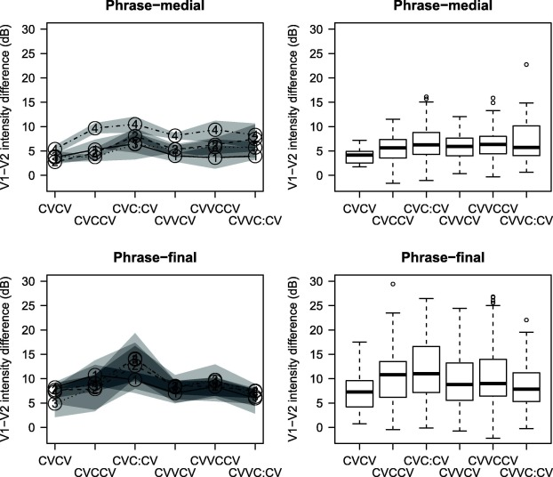

1. [Download : Download high-res image (527KB)](https://ars.els-cdn.com/content/image/1-s2.0-S0095447018300470-gr7_lrg.jpg)
2. [Download : Download full-size image](https://ars.els-cdn.com/content/image/1-s2.0-S0095447018300470-gr7.jpg)

#### 3.3.1. Words with short V1

The intensity of C2 was not affected by C2 length and the main effect of phrasal position was significant for the words with geminates [*F*(1, 49.05) = 8.50, *p* < 0.01] but not with consonant clusters. The intensity of C2 was lower in phrase-final position compared to phrase-medial position.

#### 3.3.2. Words with long V1

The main effect of C2 length was significant only for the intensity of V1 in words with short consonants and half-long consonant clusters. Before a short consonant the average intensity of a long V1 was lower (65.6 dB) than before a half-long consonant cluster (67.4 dB).

There was a significant main effect of phrasal position on the intensity of C2 ([*F*(1, 109.18) = 6.12, *p* < 0.05]) and V2 ([*F*(1, 114.89) = 8.28, *p* < 0.01]) in words with geminates. The intensity values were lower in phrase-final than in phrase-medial position. The main effect of phrasal position was statistically significant on the difference between V1 and V2 intensity in the case of both, words with geminates [*F*(1, 99.32) = 15.59, *p* < 0.001] and consonant clusters [*F*(1, 31.57) = 7.56, *p* < 0.01]. The intensity difference was greater phrase-finally than phrase-medially.

## 4. Discussion

The aim of this paper was to investigate the manifestation of the three-way consonantal quantity contrast in words with different foot structures in Inari Saami. The quantity contrast was observed by analysing segmental durations, F0 and intensity.

While the majority of the languages with the quantity category exploit a binary opposition of vowels or consonants, the phonological systems with three-way contrast are very rare. Moreover, the ternary distinction for consonants is only found in some Finnic and Saami languages. In the analysis of the three-way consonant quantity in Skolt Saami, McRobbie-Utasi (2007) discusses the instability of ternary length systems and brings out that in the phonology of Skolt Saami the three-way distinction is only a transitory stage and the system strives to be binary.

According to the results of this study the three-way distinction in consonant length in Inari Saami was most robustly realised by durational differences in the word structures with a short V1. Consonants following a long V1 did not show a difference between the durations of Q2 and Q3; the distinction between these two quantities was made by vowel duration. This result is in accordance with Bye et al. (2009) who also report a clear ternary opposition in consonant length after a short V1, but after a long vowel their results were varying between speakers. Two out of five speakers, who represented the western dialect area, realised the three-way distinction in consonant duration after a long V1, while the three speakers from the eastern dialect area did not. However, the difference between half-long and long geminates seems to be very small (around 15 ms). Our Inari speakers who come from the (north-)western dialect area, showed a two-way distinction (short vs. half-long) in these word structures. In fact, none of the individual speakers realised the three-way distinction in consonant duration after the long V1. These discrepancies between our study and the study of Bye et al. (2009) refer to the differences between dialects and to variation between speakers. This could be due to the fact that the [population density](https://www.sciencedirect.com/topics/social-sciences/population-density) is very low (the distances between villages are long) and that the distinction between different dialect areas is not straightforward.

The difference between quantities in Inari Saami is shown by the ratios of consonants presented in Table 10. After a short vowel the ratio of Q3 to Q2 geminates was greater than the ratio of Q2 geminates to Q1 consonants. Studies about other Saami languages (North, Skolt, Lule Saami; cf Table 1) have shown a smaller ratio of Q3 to Q2 geminates (the ratio ranging between 1.20 and 1.50) than Q2 to Q1 (ranging from 1.90 to 2.40). According to the results of Markus et al. (2012) the ratio of Q3/Q2 geminates in Estonian is 1.40, and in Ingrian 1.30, but in Livonian 1.78. It would have been expected to find a similar result with other Saami languages and with Estonian, but in that respect Inari Saami is similar to Livonian. In words with a long V1 the Q2 and Q3 geminates were of equal duration.

Table 10. The ratios of a half-long geminate to a short consonant (CC/C), a long geminate to a short consonant (C:C/C) and a long geminate to a half-long geminate (C:C/CC).

| V1 | CC/C | C:C/C | C:C/CC |
| --- | --- | --- | --- |
| Short | 1.53 | 2.78 | 1.82 |
| Long | 1.67 | 1.68 | 1.00 |

There is an interrelation between segments within the disyllabic foot, which is most robustly shown for the words with a short V1. The durations of both, V1 and V2 shortened with increasing consonant quantity. With a long V1 the same tendency could be seen, both vowels shortened with quantity, except that there was no difference in V2 duration after a short consonant and a half-long geminate. This shows that the distinction between Q2 and Q3 is realised in vowel duration instead of consonant duration.

The results of Bye et al. (2009) showed a similar inverse relation of segments, but they also found an unexpected temporal pattern when a long vowel was followed by a long geminate. In the speech of three speakers (two from the western and one from the eastern dialect area) V2 was longer after a long geminate than after a half-long geminate, which, as they explain, could be due to a different prosodic structure with the second syllable bearing secondary stress. In other Finno-Ugric languages that have the ternary quantity distinction, such a relation between segments has not been reported and nor did the current study find support to this suggestion, as none of the speakers showed an increase in V2 duration after a long consonant. A possible reason for this discrepancy could be that Bye et al. (2009) took the difference between open and closed second syllables into account. However, when we look at the word structures with a long V1 and closed second syllable in our data, the durations of both vowels show a decreasing trend in duration. As it can be seen in Fig. 8, the duration of V2 after a long geminate is shorter than after a half-long geminate and a short consonant. A possibility is that the differences between the studies come from different language backgrounds of the speakers.

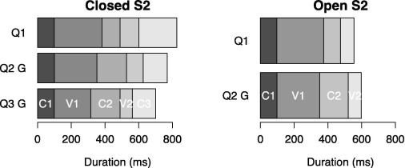

1. [Download : Download high-res image (136KB)](https://ars.els-cdn.com/content/image/1-s2.0-S0095447018300470-gr8_lrg.jpg)
2. [Download : Download full-size image](https://ars.els-cdn.com/content/image/1-s2.0-S0095447018300470-gr8.jpg)

Fig. 8. The average durations of segments in the word structures with a long V1 and closed (left panel) and open (right panel) second syllable.

Adjustments of segmental durations in the foot have been found in Estonian (Lehiste, 2003) as well in Livonian (Markus et al., 2012) where the longer primary stressed syllable is followed by a shorter vowel in the unstressed syllable. In these languages consonantal quantity does not influence the duration of V1. According to our results, in Inari Saami the durations of both vowels were affected by consonant quantity. In words with a short V1, the vowels shortened with increasing consonantal quantity and in words with a long V1 the shortening of the vowels marked the differences between short consonants and half-long geminates vs. long geminates (whereas Q2 and Q3 geminates themselves did not differ in duration). In comparison with other Saami languages with the three-way consonant quantity, Inari Saami is similar to Lule Saami (Fangel-Gustavson et al., 2014), where both, V1 and V2 shorten with increasing C2 quantity. In Skolt Saami, V1 shortens with greater consonant quantity, but there is no variation in V2 duration (McRobbie-Utasi, 2007).

Besides the temporal characteristics, the tonal movement and intensity patterns were investigated. The results of the fundamental frequency analysis showed no general effect of quantity on F0 characteristics, although there were differences in words with a short and long V1. In the case of a short V1 the F0 slope was shallower for Q3 geminates compared to Q1 consonants and Q2 geminates. This might be caused by the fact that after Q3 geminates the F0 has not fallen as low in V2 as it has after short consonants and half-long geminates. On the contrary, after Q3 consonant clusters F0 values were lower than after Q1 consonants and half-long consonant clusters. Along with the durational properties, Q3 geminates and consonant clusters after a short V1 could be differentiated from Q1 and Q2 by the characteristics of F0. In word structures with a long V1, main differences occurred during the long vowel: the average F0 was lower in the long V1 when it was followed by a short consonant than a half-long geminate or consonant cluster or a long geminate. Other Saami languages where the tonal component has been studied have exhibited some influence of quantity on F0; for example, in Lule Saami small differences in the F0 movement are claimed to be less important in the realisation of the ternary quantity contrast (Fangel-Gustavson et al., 2014). In Finnish, the variation in F0 movement with respect to quantity is small (Vainio et al., 2010) or virtually non-existent (Suomi et al., 2003). In Livonian there is no clear correlation between F0 and quantity (Tuisk, 2012). Estonian Q3 is distinctively separated from Q1 and Q2 in terms of F0: for Q3 the F0 turning point occurs earlier in the first syllable and for Q1 and Q2 it occurs close to the end of the first syllable (Lippus et al., 2013). Inari Saami seems to be placed somewhere in between these languages.

The manifestation of the three-way quantity contrast in Finnic and Saami languages is similar with respect to duration as the main correlate of quantity. However, the durational relations between segments in disyllabic feet show differences between languages. While in Inari and Lule Saami, both vowels surrounding the intervocalic consonant are affected by the quantity, in Estonian and Livonian only V2 shortens with quantity. In Estonian, the different patterns of F0 have been shown to differ in the opposition of Q1 and Q2 vs. Q3, and this in fact has a function in distinguishing between Q2 and Q3 in the perception (Lehiste, 2003). Since the durational aspects of quantity are somewhat similar in Estonian and Inari Saami, it would have been expected to find similarities in the tonal movement as well. However, the results indicated that quantity in Inari Saami involves the tonal component to a much smaller degree. This might be due to differences between the complexity of the quantity systems in the two languages. While in Estonian the three quantity degrees are contrastive for both vowels and consonants, Inari Saami exhibits the three-way distinction for consonants only. Therefore, it may be sufficient to have durational characteristics as the main correlate signalling differences between the quantity degrees. In words with a long V1, where the durations of Q2 and Q3 geminates did not differ, the durations of both V1 and V2 were significantly shortened neighbouring the Q3 consonant compared to Q1 and Q2 consonants. Furthermore, in words with a short V1 the ratio between Q2 and Q3 geminates in Inari Saami was considerably larger than it is for Estonian clearly showing the distinction of half-long geminates from long ones.

This study showed that the three-way quantity contrast in Inari Saami is a foot level phenomenon realised mainly by durational properties along with tonal and intensity characteristics. As a next step, further research is needed for clarifying the role of fundamental frequency movement in the perception of quantity. Additionally, in this study test words were read in two different phrasal positions, which in the statistical tests showed no interactions with quantity, i.e., the effect of quantity on consonant duration was similar regardless of the phrasal position of the word. However, further studies could test quantity effects in different phrasal positions. The effects of microprosodic variation on quantity realisation could also be addressed in a subsequent study.

## 5. Conclusion

In this paper the three-way quantity contrast of consonants is studied, considering the features of duration, fundamental frequency and intensity. The ternary opposition of consonant quantity is manifested in a disyllabic foot and is most clearly realised in consonant duration after a short V1, where C2 is either short, half-long or long. The duration ratio of half-long geminates to long geminates in these word structures is greater than the ratio of short consonants to half-long geminates. The durations of the adjacent short vowels decrease with increasing consonant quantity with greater impact on V2. In feet with a long V1 there is no difference between the durations of half-long and long geminates, but the surrounding vowels are shorter next to long geminates as compared to half-long geminates and short consonants. Therefore, while the consonant duration stays the same, it is the duration of vowels that makes the overall quantity distinction.

While the segmental durations are adjusted, the fundamental frequency contours vary less in different word structures. In words with a short V1, long geminates differ from short consonants and half-long geminates in having a shallower F0 slope. In words with a long V1, the average F0 of V1 is higher when the vowel is followed by a half-long or long geminate than a short consonant. Quantity somewhat affects the intensity of the surrounding vowels, especially V2, where the intensity is lowered with increasing consonant quantity.

## Acknowledgements

The authors would like to thank all the Inari Saami test subjects. We are very grateful to anonymous reviewers for their insightful comments and suggestions. We would like to thank Eva Liina Asu for proof-reading the paper, and Virve-Anneli Vihman and Joshua Wilbur for their helpful comments on language use. This research was supported by Estonian Research Agency grant No. IUT2-37.

## Competing interests

The authors declare that they have no competing interests.

## Appendix A. Supplementary data

The following are the Supplementary data to this article:[Download : Download XML file (1012B)](https://ars.els-cdn.com/content/image/1-s2.0-S0095447018300470-mmc1.xml)

Supplementary data 1.

## Research data for this article

Inari Saami geminates

Original Data

Data extracted from the Inari Saami prosody corpus (http://dx.doi.org/10.15155/1-00-0000-0000-0000-00150L), used in Türk et al. (2018). The Acoustic Correlates of Quantity in Inari Saami. Journal of Phonetics. Target words with six different foot structures were used: CVCV, CVCCV, CVC:CV(C), CVVCV(C), CVVCCV(C), CVVC:CVC. In total there were 1463 words included in the analysis of durations, 1043 for fundamental frequency and 597 for intensity measures.

[Get data from DataDOI](http://dx.doi.org/10.15155/re-57)

[Further information on research data](https://service.elsevier.com/app/answers/detail/a_id/35539/c/10546/supporthub/sciencedirect/)

## References

**Aikio-Puoskari, 2009**

Aikio-Puoskari, U. (2009). The ethnic revival, language and education of the Sámi, an indigenous people, in three Nordic Countries (Finland, Norway and Sweden). Multilingual Education for Social Justice: Globalising the Local (pp. 216–237).

Google Scholar

**Äimä, 1914**

Äimä, F. (1914). Phonetik und Lautlehre des Inarilappischen: Akademische Abhandlung; mit 96 Abb. in 2. Ser.(Taf.).

[Google Scholar](https://scholar.google.com/scholar?q=%C3%84im%C3%A4,%20F.%20.%20Phonetik%20und%20Lautlehre%20des%20Inarilappischen:%20Akademische%20Abhandlung;%20mit%2096%20Abb.%20in%202.%20Ser..)

**Baal et al., 2012**

B.A.B. Baal, D. Odden, C. Rice

**An analysis of North Saami gradation**

Phonology, 29 (2) (2012), pp. 165-212

[Google Scholar](https://scholar.google.com/scholar_lookup?title=An%20analysis%20of%20North%20Saami%20gradation&publication_year=2012&author=B.A.B.%20Baal&author=D.%20Odden&author=C.%20Rice)

**Bals et al., 2007**

Bals, B. A., Odden, D., & Rice, C. (2007). The phonology of gradation in North Saami. Retrieved 2 June 2017, from https://pdfs.semanticscholar.org/12d2/79643142ed361a707c49f3f138af9eccb2d6.pdf?_ga=2.2489264.1072500119.1539693890-114557159.1516011322.

Google Scholar

**Bates et al., 2014**

D. Bates, M. Maechler, B. Bolker, S. Walker

**lme4: Linear mixed-effects models using Eigen and S4**

R Package Version, 1 (7) (2014)

Google Scholar

**Bhatia and Ritchie, 2008**

T.K. Bhatia, W.C. Ritchie

**The handbook of bilingualism**

John Wiley & Sons (2008)

[Google Scholar](https://scholar.google.com/scholar_lookup?title=The%20handbook%20of%20bilingualism&publication_year=2008&author=T.K.%20Bhatia&author=W.C.%20Ritchie)

**Boersma and Weenink, 2017**

Boersma, P., & Weenink, D. (2017). Praat: doing phonetics by computer (Version 6.0.18). Retrieved from http://www.praat.org/.

[Google Scholar](https://scholar.google.com/scholar?q=Boersma,%20P.,%20%20Weenink,%20D.%20.%20Praat:%20doing%20phonetics%20by%20computer%20.%20Retrieved%20from%20http:www.praat.org.)

**Bye, 2007**

P. Bye

**Grade alternation in Inari Saami and abstract declarative phonology**

Saami Linguistics, 288 (2007), pp. 53-90

[CrossRef](https://doi.org/10.1075/cilt.288.04bye)[View Record in Scopus](https://www.scopus.com/inward/record.url?eid=2-s2.0-84945379903&partnerID=10&rel=R3.0.0)[Google Scholar](https://scholar.google.com/scholar_lookup?title=Grade%20alternation%20in%20Inari%20Saami%20and%20abstract%20declarative%20phonology&publication_year=2007&author=P.%20Bye)

**Bye et al., 2009**

P. Bye, E. Sagulin, I. Toivonen

**Phonetic duration, phonological quantity and prosodic structure in Inari Saami**

Phonetica, 66 (4) (2009), pp. 199-221

[View Record in Scopus](https://www.scopus.com/inward/record.url?eid=2-s2.0-77951851910&partnerID=10&rel=R3.0.0)Google Scholar

**Eek and Meister, 1997**

A. Eek, E. Meister

**Simple perception experiments on Estonian word prosody: Foot structure vs. segmental quantity**

Estonian prosody: Papers from a symposium, Institute of Estonian Language, Tallinn, Estonia (1997), pp. 71-99

Google Scholar

**Fangel-Gustavson et al., 2014**

Fangel-Gustavson, N., Ridouane, R., & Morén-Duolljá, B. (2014). Quantity contrast in Lule Saami: a threeway system. Proceedings of 10th ISSP (pp. 106–109).

Google Scholar

**Feist, 2010**

T. Feist

**A grammar of Skolt Saami**

(PhD Thesis)

University of Manchester, Manchester (2010)

[Google Scholar](https://scholar.google.com/scholar_lookup?title=A%20grammar%20of%20Skolt%20Saami&publication_year=2010&author=T.%20Feist)

**Fernandez-Vest, 2012**

M.M.J. Fernandez-Vest

**Sami: An introduction to the language and culture**

Finn Lectura, Helsinki (2012)

[Google Scholar](https://scholar.google.com/scholar_lookup?title=Sami%3A%20An%20introduction%20to%20the%20language%20and%20culture&publication_year=2012&author=M.M.J.%20Fernandez-Vest)

**Hasselbrink, 1981**

G. Hasselbrink

**Südlappisches Wörterbuch I-III**

Skr Dialekt-Och Folkminnesarkivet I Uppsala, Ser C, 1985 (4) (1981), pp. 1-1488

[Google Scholar](https://scholar.google.com/scholar_lookup?title=S%C3%BCdlappisches%20W%C3%B6rterbuch%20I-III&publication_year=1981&author=G.%20Hasselbrink)

**Hoogshagen, 1959**

S. Hoogshagen

**Three contrastive vowel lengths in Mixe**

STUF-Language Typology and Universals, 12 (1–4) (1959), pp. 111-115

[View Record in Scopus](https://www.scopus.com/inward/record.url?eid=2-s2.0-42649088560&partnerID=10&rel=R3.0.0)[Google Scholar](https://scholar.google.com/scholar_lookup?title=Three%20contrastive%20vowel%20lengths%20in%20Mixe&publication_year=1959&author=S.%20Hoogshagen)

**Itkonen, 1946**

E. Itkonen

**Struktur und Entwicklung der ostlappischen Quantitätssysteme**

Mémoires de La Société Finno-Ougrienne, 88 (1946)

[Google Scholar](https://scholar.google.com/scholar_lookup?title=Struktur%20und%20Entwicklung%20der%20ostlappischen%20Quantit%C3%A4tssysteme&publication_year=1946&author=E.%20Itkonen)

**Itkonen et al., 1989**

E. Itkonen, R. Bartens, L. Laitinen

Inarilappisches Wörterbuch, Vol. 20 (1989)

**Leer, 1985**

Leer, J. (1985). Toward a metrical interpretation of Yupik prosody. Yupik eskimo prosody systems: descriptive and comparative studies, Alaska native language center research papers, fairbanks (pp. 159–173).

Google Scholar

**Lehiste, 1960**

I. Lehiste

**Segmental and syllabic quantity in Estonian**

American Studies in Uralic Linguistics, 1 (1960), pp. 21-82

[Google Scholar](https://scholar.google.com/scholar_lookup?title=Segmental%20and%20syllabic%20quantity%20in%20Estonian&publication_year=1960&author=I.%20Lehiste)

**Lehiste, 2003**

I. Lehiste

**Prosodic change in progress: From quantity language to accent language**

P. Fikkert, H. Jacobs (Eds.), Development in prosodic systems, Mouton de Gruyter, Berlin, New York (2003), pp. 47-65

[View Record in Scopus](https://www.scopus.com/inward/record.url?eid=2-s2.0-70350181038&partnerID=10&rel=R3.0.0)[Google Scholar](https://scholar.google.com/scholar_lookup?title=Prosodic%20change%20in%20progress%3A%20From%20quantity%20language%20to%20accent%20language&publication_year=2003&author=I.%20Lehiste)

**Lehiste et al., 2008**

I. Lehiste, P. Teras, V. Ernštreits, P. Lippus, K. Pajusalu, T. Tuisk, T.-R. Viitso

**Livonian prosody**

Suomalais-Ugrilainen Seura, Helsinki (2008)

Google Scholar

**Lehtinen, 2007**

T. Lehtinen

**Kielen vuosituhannet: suomen kielen kehitys kantauralista varhaissuomeen**

Suomalaisen Kirjallisuuden Seura (2007)

[Google Scholar](https://scholar.google.com/scholar_lookup?title=Kielen%20vuosituhannet%3A%20suomen%20kielen%20kehitys%20kantauralista%20varhaissuomeen&publication_year=2007&author=T.%20Lehtinen)

**Lehtiranta, 1992**

J. Lehtiranta

Arjeploginsaamen äänne-ja taivutusopin pääpiirteet, Vol. Mémoires de la Société Finno-Ougrienne 212 (1992)

**Lippus et al., 2013**

P. Lippus, E.L. Asu, P. Teras, T. Tuisk

**Quantity-related variation of duration, pitch and vowel quality in spontaneous Estonian**

Journal of Phonetics, 41 (1) (2013), pp. 17-28

[Article](https://www.sciencedirect.com/science/article/pii/S0095447012000721)[Download PDF](https://www.sciencedirect.com/science/article/pii/S0095447012000721/pdfft?md5=9f1a96eafd21ff38f15219a370384a7c&pid=1-s2.0-S0095447012000721-main.pdf)[View Record in Scopus](https://www.scopus.com/inward/record.url?eid=2-s2.0-84870197800&partnerID=10&rel=R3.0.0)Google Scholar

**Lippus et al., 2018**

Lippus, P., Teras, P., Pajusalu, K., & Türk, H. (2018). Inari Sami prosody corpus. Retrieved from https://doi.org/10.15155/1-00-0000-0000-0000-00150L.

Google Scholar

**Magga, 1984**

T. Magga

Duration in the quantity of bisyllabics in the Guovdageaidnu dialect of North Lappish, Vol 11, University of Oulu (1984)

**Markus et al., 2012**

Markus, E., Lippus, P., Pajusalu, K., & Teras, P. (2012). Three-way opposition of consonant quantity in Finnic and Saamic languages. In Nordic prosody: Proceedings of the 11th conference (pp. 225–234). Tartu.

Google Scholar

**McRobbie-Utasi, 2007**

McRobbie-Utasi, Z. (2007). The instability of systems with ternary length distinctions: The Skolt Saami evidence. Amsterdam Studies in the Theory and History of Linguistic Science Series 4, 288 (pp. 167–205).

Google Scholar

**Morottaja et al., 2012**

Morottaja, P., Kuuva, P., & Olthuis, M.-L. (2012). Kielâkyeimi 1. Sämitigge.

[Google Scholar](https://scholar.google.com/scholar?q=Morottaja,%20P.,%20Kuuva,%20P.,%20%20Olthuis,%20M.-L.%20.%20Kiel%C3%A2kyeimi%201.%20S%C3%A4mitigge.)

**Olthuis, 2000**

M.-L. Olthuis

**Inarinsaamen kielen vuosisadat**

Virittäjä, 104 (4) (2000)

568–568

[Google Scholar](https://scholar.google.com/scholar_lookup?title=Inarinsaamen%20kielen%20vuosisadat&publication_year=2000&author=M.-L.%20Olthuis)

**Pasanen, 2015**

A. Pasanen

**Kuávsui já peeivičuovâ. ‘Sarastus ja päivänvalo’: Inarinsaamen kielen revitalisaatio**

University of Helsinki and Finno-Ugrian Society (2015)

[Google Scholar](https://scholar.google.com/scholar?q=Ku%C3%A1vsui%20j%C3%A1%20peeivi%C4%8Duov%C3%A2.%20Sarastus%20ja%20p%C3%A4iv%C3%A4nvalo:%20Inarinsaamen%20kielen%20revitalisaatio)

**Prehn, 2012**

M. Prehn

**Vowel quantity and the fortis-lenis distinction in North Low Saxon**

LOT (2012)

[Google Scholar](https://scholar.google.com/scholar_lookup?title=Vowel%20quantity%20and%20the%20fortis-lenis%20distinction%20in%20North%20Low%20Saxon&publication_year=2012&author=M.%20Prehn)

**Remijsen and Gilley, 2008**

B. Remijsen, L. Gilley

**Why are three-level vowel length systems rare? Insights from Dinka (Luanyjang dialect)**

Journal of Phonetics, 36 (2) (2008), pp. 318-344

[Article](https://www.sciencedirect.com/science/article/pii/S0095447007000344)[Download PDF](https://www.sciencedirect.com/science/article/pii/S0095447007000344/pdfft?md5=bdf0e77aa81a4eac04d62a46e0f3c0d0&pid=1-s2.0-S0095447007000344-main.pdf)[View Record in Scopus](https://www.scopus.com/inward/record.url?eid=2-s2.0-42649097211&partnerID=10&rel=R3.0.0)[Google Scholar](https://scholar.google.com/scholar?q=Why%20are%20three-level%20vowel%20length%20systems%20rare%20Insights%20from%20Dinka)

**Sammallahti, 1998**

P. Sammallahti

**The Saami languages: An introduction**

Davvi girji, Karasjok, Norway (1998)

[Google Scholar](https://scholar.google.com/scholar_lookup?title=The%20Saami%20languages%3A%20An%20introduction&publication_year=1998&author=P.%20Sammallahti)

**Sammallahti and Morottaja, 1993**

Sammallahti, P., & Morottaja, M. (1993). Säämi-suomâ sänikirje: Inarinsaamelais-suomalainen sanakirja. Girjegiisá.

[Google Scholar](https://scholar.google.com/scholar?q=Sammallahti,%20P.,%20%20Morottaja,%20M.%20.%20S%C3%A4%C3%A4mi-suom%C3%A2%20s%C3%A4nikirje:%20Inarinsaamelais-suomalainen%20sanakirja.%20Girjegiis%C3%A1.)

**Schlachter, 1958**

W. Schlachter

Wörterbuch des Waldlappendialekts von Malå und Texte zur Ethnographie, Vol. 14, Suomalais-Ugrilainen Seura, Helsinki (1958)

**Suomi et al., 2003**

K. Suomi, J. Toivanen, R. Ylitalo

**Durational and tonal correlates of accent in Finnish**

Journal of Phonetics, 31 (1) (2003), pp. 113-138

[Article](https://www.sciencedirect.com/science/article/pii/S0095447002000748)[Download PDF](https://www.sciencedirect.com/science/article/pii/S0095447002000748/pdfft?md5=5a91940b04e5551167ad20d0f047a8f1&pid=1-s2.0-S0095447002000748-main.pdf)[View Record in Scopus](https://www.scopus.com/inward/record.url?eid=2-s2.0-0037229274&partnerID=10&rel=R3.0.0)[Google Scholar](https://scholar.google.com/scholar_lookup?title=Durational%20and%20tonal%20correlates%20of%20accent%20in%20Finnish&publication_year=2003&author=K.%20Suomi&author=J.%20Toivanen&author=R.%20Ylitalo)

**Thomas and Shaterian, 1990**

K.D. Thomas, A. Shaterian

**Vowel length and pitch in Yavapai**

UCLA Working Papers in Phonetics, 78 (1990), p. 87

[View Record in Scopus](https://www.scopus.com/inward/record.url?eid=2-s2.0-85057457108&partnerID=10&rel=R3.0.0)[Google Scholar](https://scholar.google.com/scholar_lookup?title=Vowel%20length%20and%20pitch%20in%20Yavapai&publication_year=1990&author=K.D.%20Thomas&author=A.%20Shaterian)

**Thomas, 1992**

Thomas, K. D. (1992). Vowel length in Yavapai revisited. In J. E. Redden (Ed.), Papers from the Honkan-Penutian Language Conference and the J. P. Harrington Conference (pp. 90–131). Santa Barbara, CA.

Google Scholar

**Tuisk, 2012**

T. Tuisk

**Tonal and temporal characteristics of disyllabic words in spontaneous Livonian**

Linguistica Uralica, 48 (1) (2012)

[Google Scholar](https://scholar.google.com/scholar_lookup?title=Tonal%20and%20temporal%20characteristics%20of%20disyllabic%20words%20in%20spontaneous%20Livonian&publication_year=2012&author=T.%20Tuisk)

**Türk et al., 2014**

Türk, H., Lippus, P., Pajusalu, K., & Teras, P. (2014). The ternary contrast of consonant duration in Inari Saami. Proceedings of 7th Speech Prosody (pp. 361–364).

Google Scholar

**Türk et al., 2015**

H. Türk, P. Lippus, K. Pajusalu, P. Teras

**Temporal patterns of quantity in Inari Saami**

University of Glasgow, Glasgow, UK (2015)

[Google Scholar](https://scholar.google.com/scholar_lookup?title=Temporal%20patterns%20of%20quantity%20in%20Inari%20Saami&publication_year=2015&author=H.%20T%C3%BCrk&author=P.%20Lippus&author=K.%20Pajusalu&author=P.%20Teras)

**Türk et al., 2016**

H. Türk, P. Lippus, K. Pajusalu, P. Teras

**Quantity contrast in Inari Saami: the role of pitch and intensity**

Speech Prosody, 2016 (2016), pp. 1090-1094

[View Record in Scopus](https://www.scopus.com/inward/record.url?eid=2-s2.0-84982976221&partnerID=10&rel=R3.0.0)Google Scholar

**Vainio et al., 2010**

M. Vainio, J. Järvikivi, D. Aalto, A. Suni

**Phonetic tone signals phonological quantity and word structure**

The Journal of the Acoustical Society of America, 128 (3) (2010), pp. 1313-1321

https://doi.org/https://doi.org/10.1121/1.3467767

[CrossRef](https://doi.org/10.1121/1.3467767)[View Record in Scopus](https://www.scopus.com/inward/record.url?eid=2-s2.0-77956401977&partnerID=10&rel=R3.0.0)Google Scholar

**von Gertten, 2015**

D.Z. von Gertten

*Huvuddrag i umesamisk grammatik* (Masteroppgåve)

Universitetet i Oslo (2015)

[Google Scholar](https://scholar.google.com/scholar?q=Huvuddrag%20i%20umesamisk%20grammatik)

**Wilbur, 2007**

J. Wilbur

**Syllable Structures and Stress Patterns in Kildin Saami**

(MA Thesis)

Universität Leipzig (2007)

[Google Scholar](https://scholar.google.com/scholar_lookup?title=Syllable%20Structures%20and%20Stress%20Patterns%20in%20Kildin%20Saami&publication_year=2007&author=J.%20Wilbur)

**Wilbur, 2014**

J. Wilbur

**A grammar of Pite Saami**

Language Science Press, Berlin (2014)

[Google Scholar](https://scholar.google.com/scholar_lookup?title=A%20grammar%20of%20Pite%20Saami&publication_year=2014&author=J.%20Wilbur)

## Cited by (4)

### Dialectal variation of duration patterns in Finnmark North Sámi quantity

- 2020, Journal of the Acoustical Society of America

### The role of duration and pitch in signaling quantity in Finnmark North Sámi

- 2020, Proceedings of the International Conference on Speech Prosody

### Temporal patterns of geminates in Inari Saami trisyllabic words

- 2020, Proceedings of the International Conference on Speech Prosody

### Interactions between segmental context and quantity: Temporal patterns of geminates in Estonian

- 2019, Linguistica Uralica

**<sup>1</sup>**

Different authors use these terms differently; for example, some (e.g., Bye et al., 2009) use ‘half-long’ and ‘long consonants’, others (e.g., Markus et al., 2012) use ‘short’ and ‘long geminates’. In this paper the terms ‘short consonants’, ‘half-long geminates’, and ‘long geminates’ are used throughout.

**<sup>2</sup>**

In the dictionary /p, t, k, s/ are only marked with a single or a double letter, indicating that there is no Q2 for these consonants. However, according to the inflectional classes of words with these sounds in intervocalic position between V1 and V2, they should exist in Q2 as well. It may be that the dictionary does not make this distinction in spelling. Nevertheless, our data seems to support the fact that Q2 also exists for /p, t, k, s/. In addition, spelling could have an influence on pronunciation, but since our test subjects represent the older generation of the native Inari Saami speakers who acquired the language in their childhood, the spelling of the words should have minimal or no impact on their pronunciation.

**<sup>3</sup>**

Our data are not balanced in terms of the number of different consonants used and the reader should keep in mind that microprosodic variation could potentially have an impact on the realisation of quantity.

[View Abstract](https://www.sciencedirect.com/science/article/abs/pii/S0095447018300470)

© 2018 Elsevier Ltd. All rights reserved.

- Journal of Phonetics, Volume 73, 2019, pp. 128-143

- Journal of Phonetics, Volume 75, 2019, pp. 43-56

- Journal of Phonetics, Volume 73, 2019, pp. 113-127

12

Citations

- Citation Indexes: 4

Captures